# Novel Saints Database Coordinator

## About me

- Social historian
- **Doctoral thesis**: Roman identity in the eastern Mediterranean after the Arab conquests
- **Research interests**: - Mountains in Late Antiquity - Hagiography as a literary genre
- Instructor of Greek and Late Antique history

[figure not shown]

## Organizer and administrator

### Leadership and project management

- Seminars, conferences, and professional organizations
- Language (Greek, Syriac, Coptic) and literature reading groups

### Digital and IT skills

- Website creation and maintenance
- Coding and modding
- Graphical design
- Administrative assistant and database management

## Ideas for database

### Comprehensiveness

- Should ‘love’ be the exclusive category for consideration of inclusion?
- Non-Christian hagiography - Relatively numerous and diverse

### Utility

- Cross-database referencing - *Alexander Romance*: biography combining realistic and fantastic elements
- Mapping

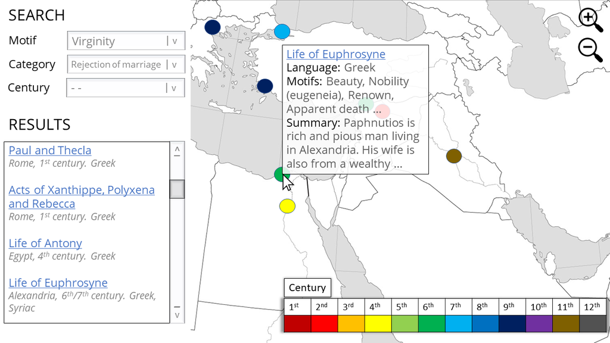

## Travelogues and landscape *ekphrasis*

### Major themes

- Interaction of space, movement and identity
- Projected feelings and expectations
- Landscape in the ‘local’ and ‘foreign’ immagination
- Environmental history
- Groupness (e.g. ethno-linguistic or religious) and the concept of belonging to a place

[figure not shown]

*The world tabernacle of Kosmas Indicopleustes, 6th century*

## Modelling hagiography as a literary genre

[figure not shown]

*Simeon Stylites the Younger*

### ‘Spritual Realism’

- Developed from pedagogy
- Inspired by parallels with 20th-century *magical realism* movement
- Thesis: both mundane and spiritual aspects of hagiographies are *realist*
- Implication: hagiographies are governed by rules for their depiction of both worldly and miraculous events

## Summary

### Social historian

- Greek, Syriac and Coptic source materials

### Project management experience

- IT skills

### Database expansion: mapping

- Coordinate with other projects

### Interests in landscape and theorizing genre

- Making hagiography more approachable

### **Thank you!**

## *Roman Identity in Transition from the Arab Conquests to the Triumph of Orthodoxy*

- Focus of DFG stipendiary fellowship at University of T?bingen (through 30 April).
- Under contract with Palgrave-Macmillan. On track for submission in mid-May.

**Abstract**: *This work offers a necessary correction to a set of entrenched distortions in the way historians have read Roman identity in the period. I show that Roman identity remained relevant as a social and political identity in the seventh, eighth, and early ninth centuries AD. In contrast to long-established views, I demonstrate that there is continuity of Roman group identity in the Eastern Mediterranean throughout these centuries. My book is set apart by its tight chronological focus, explicitly delving into one of the most historiographically-challenging periods of the history of the Roman people.*